# Visualizacion - Comunicar con Graficos

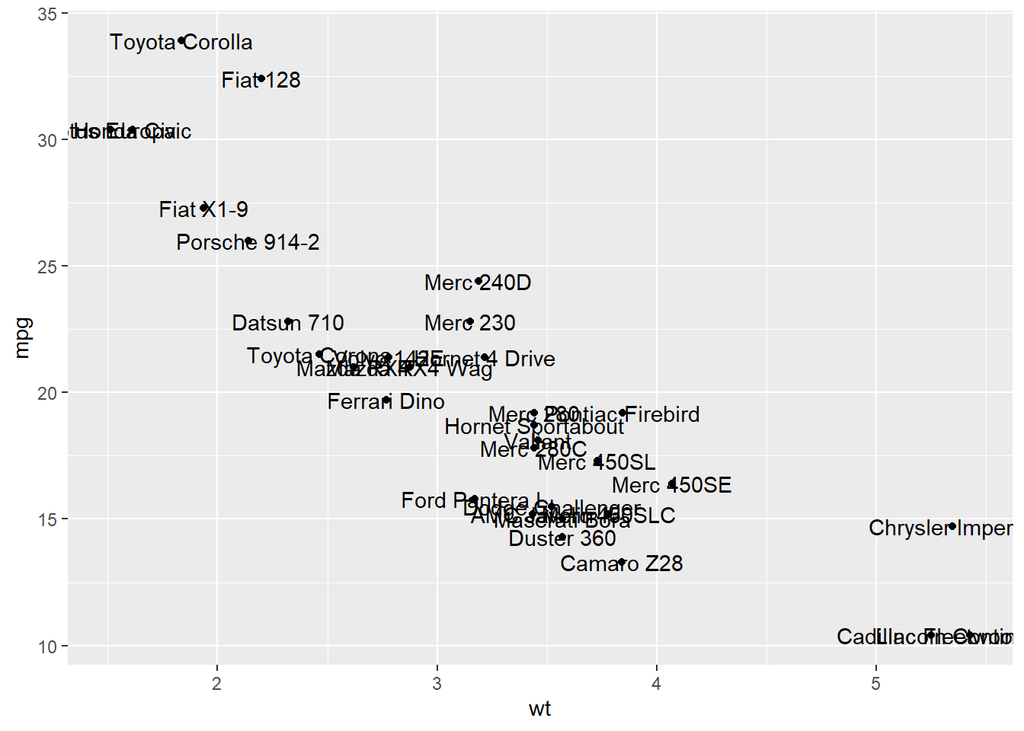

```r
p <- ggplot(mtcars, aes(wt, mpg, label = rownames(mtcars))) +
   geom_point()

p + geom_text()
```

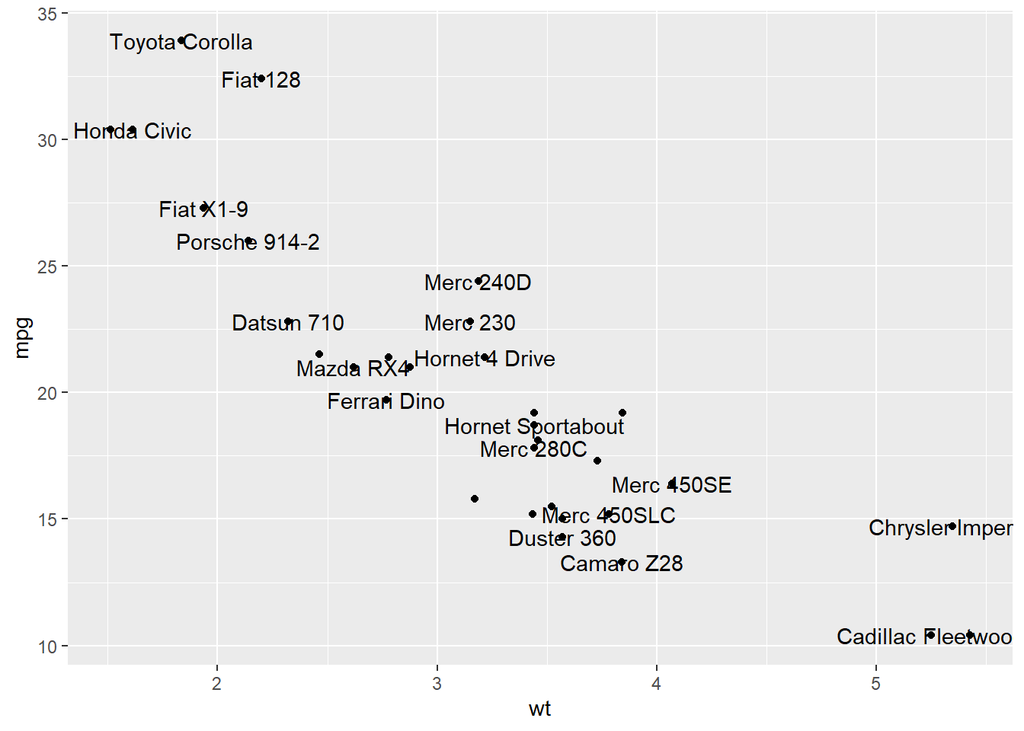

```r
# Avoid overlaps
p + geom_text(check_overlap = TRUE)
```

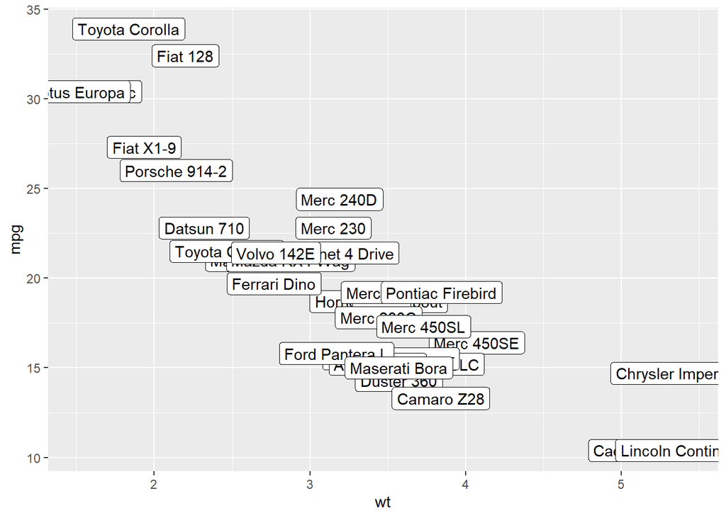

```r
# Labels with background
p + geom_label()
```

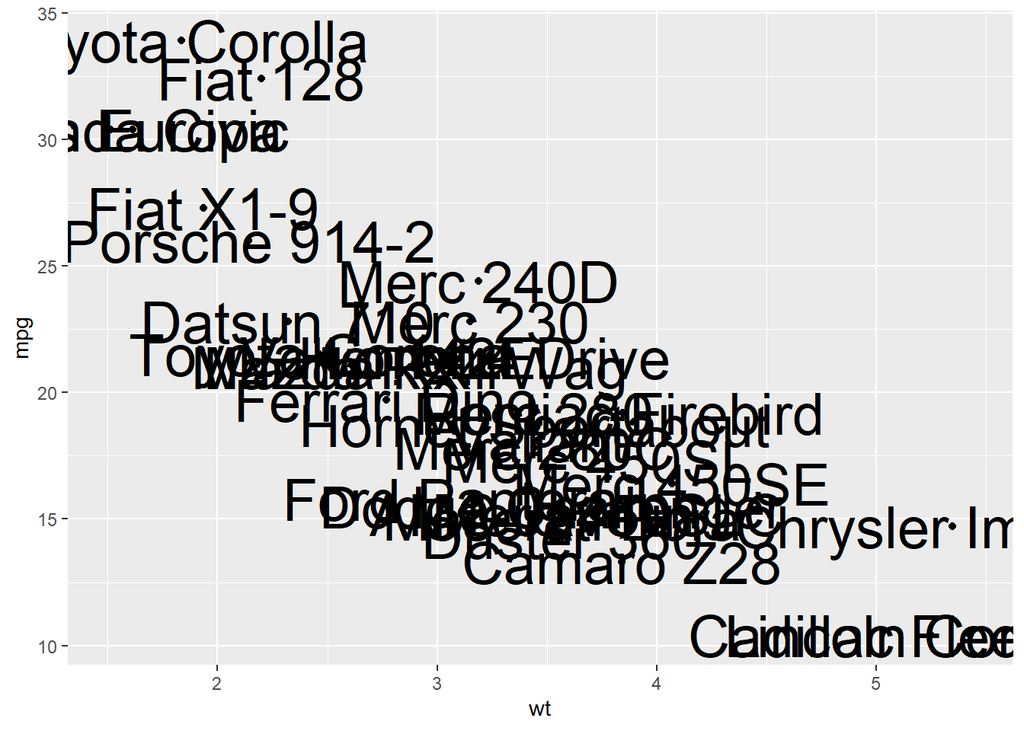

```r
# Change size of the label
p + geom_text(size = 10)
```

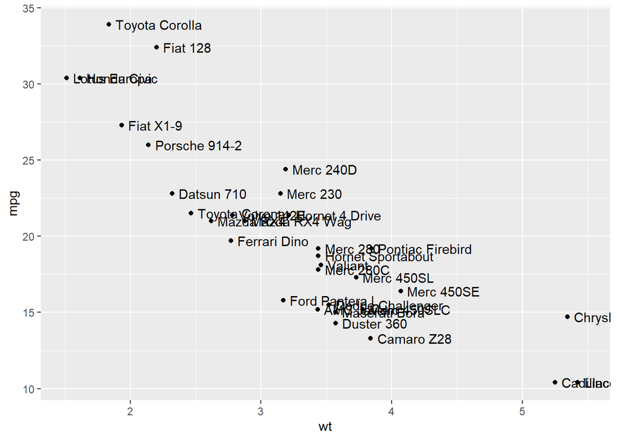

```r
# Set aesthetics to fixed value
p + geom_point() + geom_text(hjust = 0, nudge_x = 0.05)
```

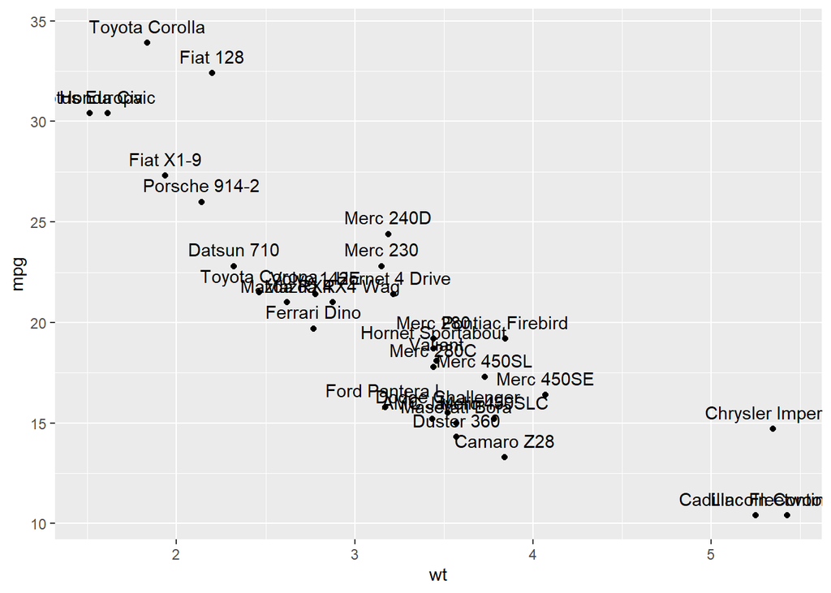

```r
p + geom_point() + geom_text(vjust = 0, nudge_y = 0.5)
```

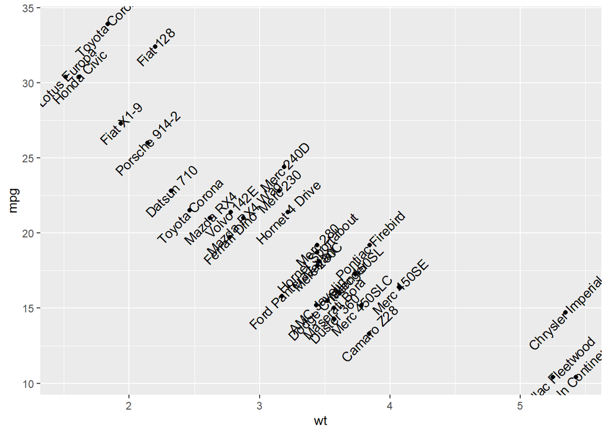

```r
p + geom_point() + geom_text(angle = 45)
```

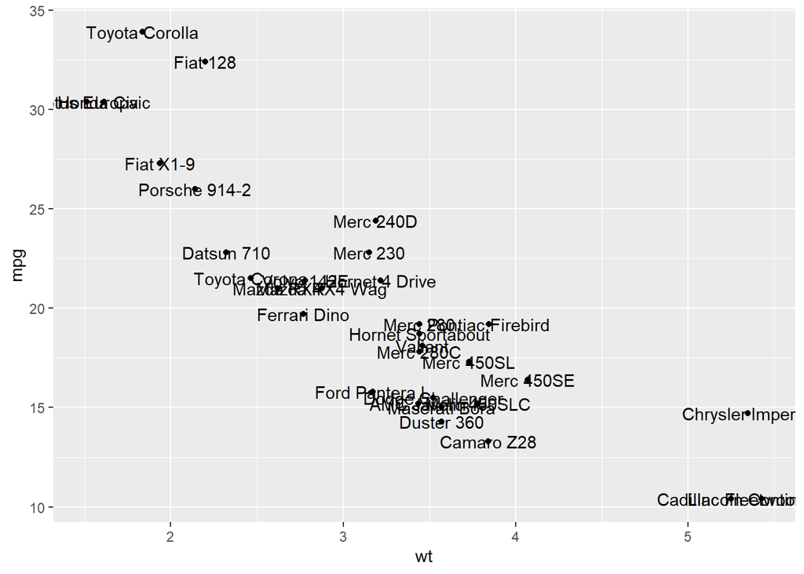

```r
## Not run:
# Doesn't work on all systems
p + geom_text(family = "Times New Roman")
```

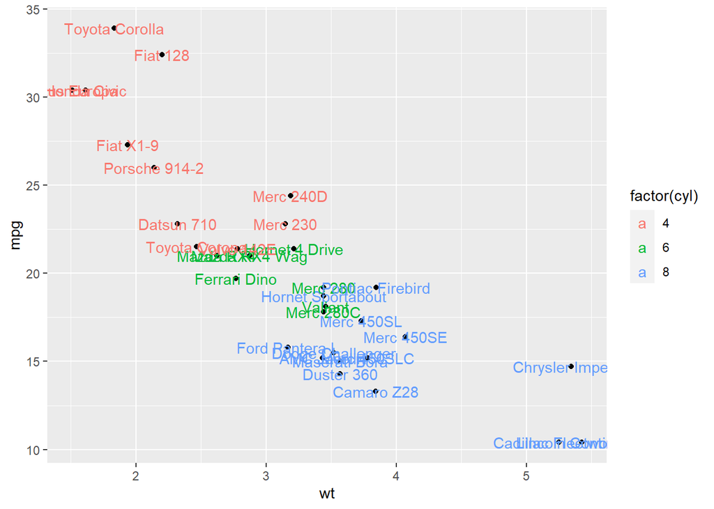

```r
## End(Not run)

# Add aesthetic mappings
p + geom_text(aes(colour = factor(cyl)))
```

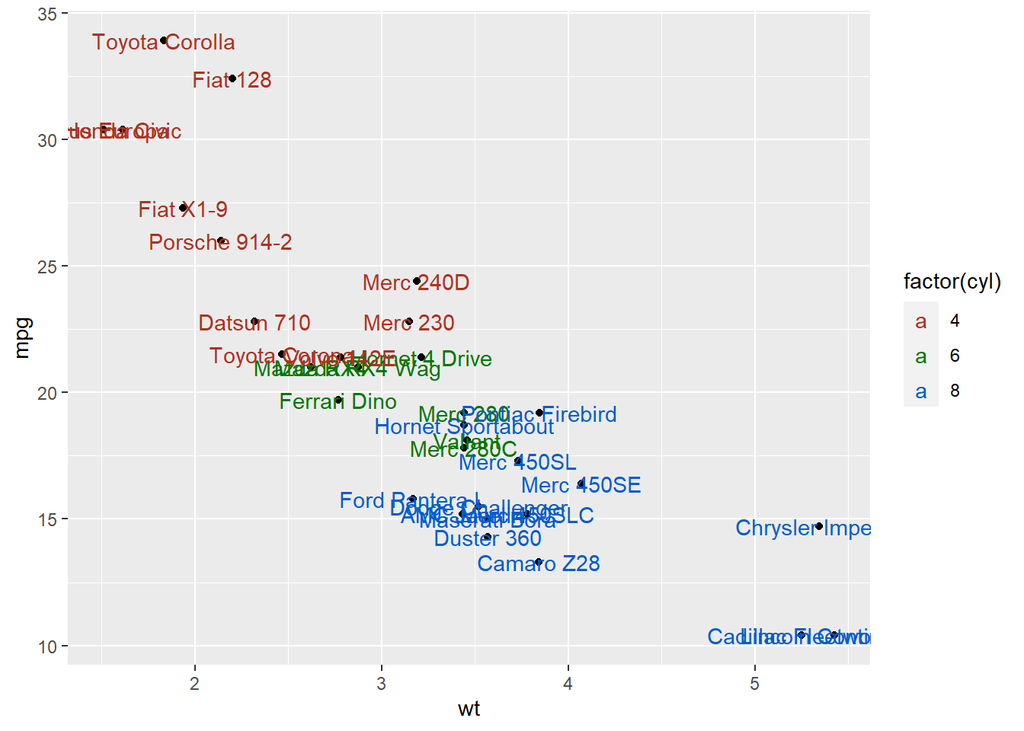

```r
p + geom_text(aes(colour = factor(cyl))) +
  scale_colour_discrete(l = 40)
```

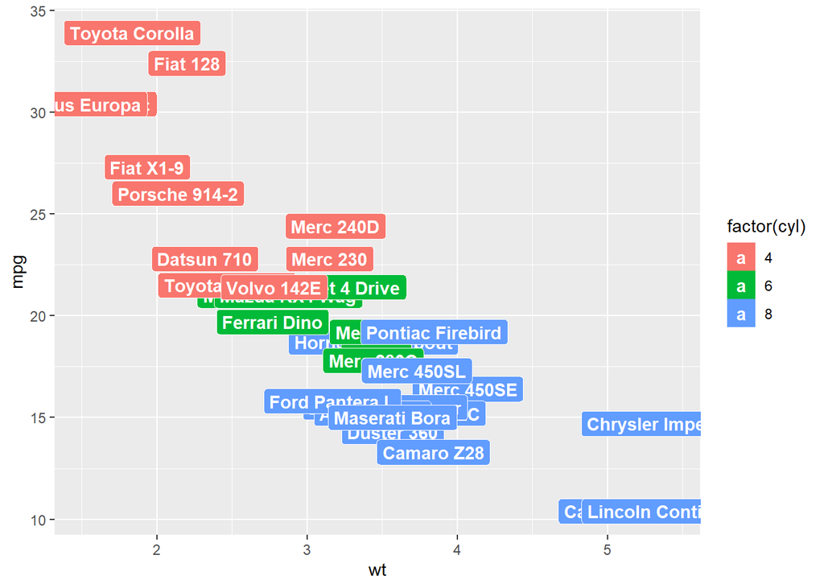

```r
p + geom_label(aes(fill = factor(cyl)), colour = "white", fontface = "bold")
```

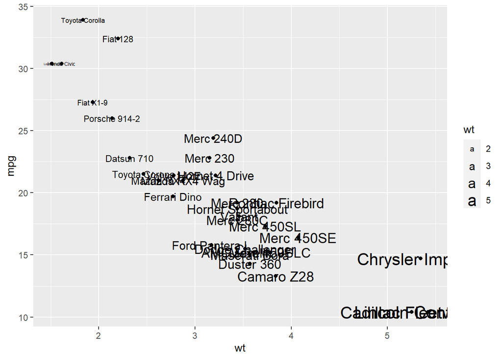

```r
p + geom_text(aes(size = wt))
```

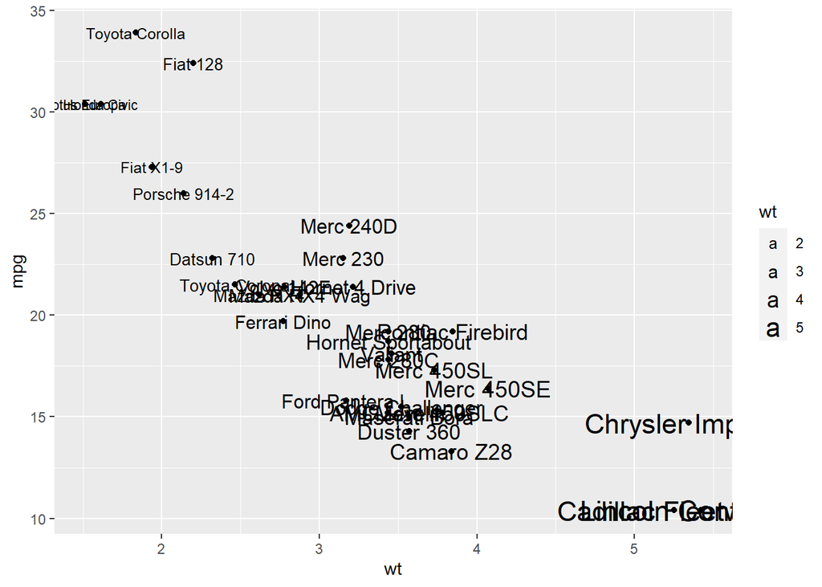

```r
# Scale height of text, rather than sqrt(height)
p + geom_text(aes(size = wt)) + scale_radius(range = c(3,6))
```

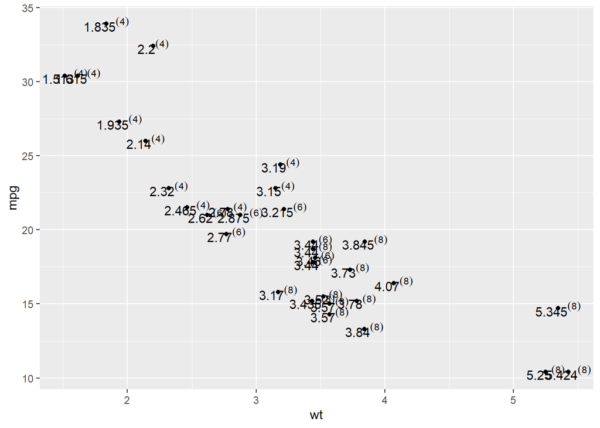

```r
# You can display expressions by setting parse = TRUE.  The
# details of the display are described in ?plotmath, but note that
# geom_text uses strings, not expressions.
p + geom_text(aes(label = paste(wt, "^(", cyl, ")", sep = "")),
  parse = TRUE)
```

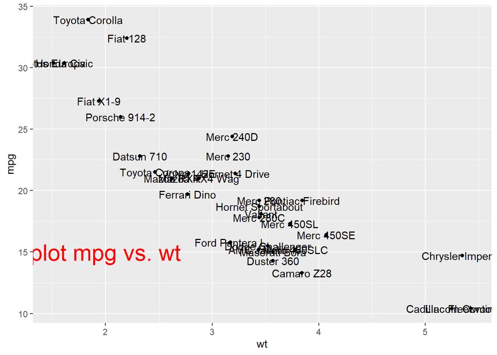

```r
# Add a text annotation
p +
  geom_text() +
  annotate("text", label = "plot mpg vs. wt", x = 2, y = 15, size = 8, colour = "red")
```

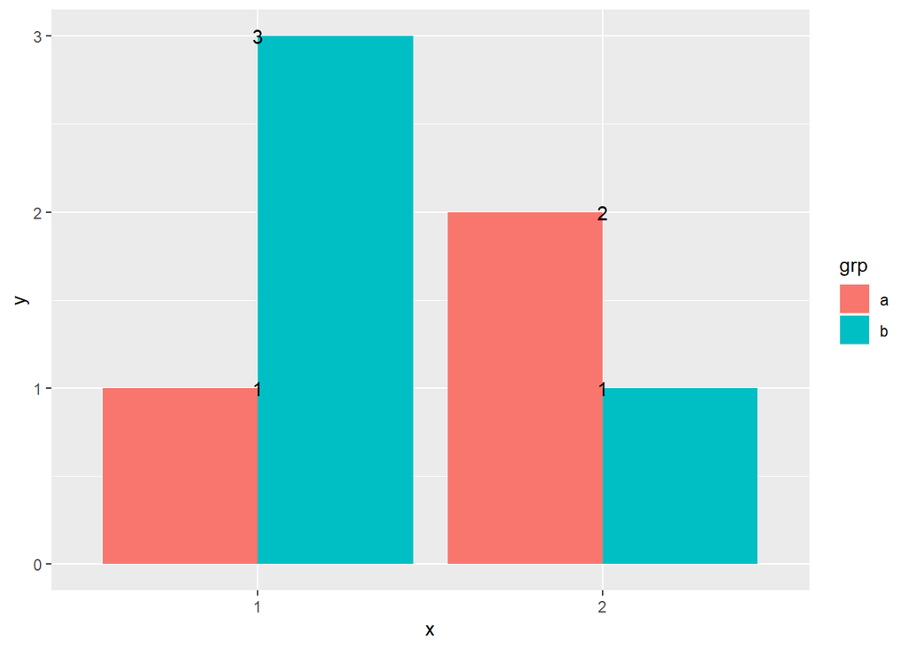

```r
# Aligning labels and bars --------------------------------------------------
df <- data.frame(
  x = factor(c(1, 1, 2, 2)),
  y = c(1, 3, 2, 1),
  grp = c("a", "b", "a", "b")
)

# ggplot2 doesn't know you want to give the labels the same virtual width
# as the bars:
ggplot(data = df, aes(x, y, group = grp)) +
  geom_col(aes(fill = grp), position = "dodge") +
  geom_text(aes(label = y), position = "dodge")
```

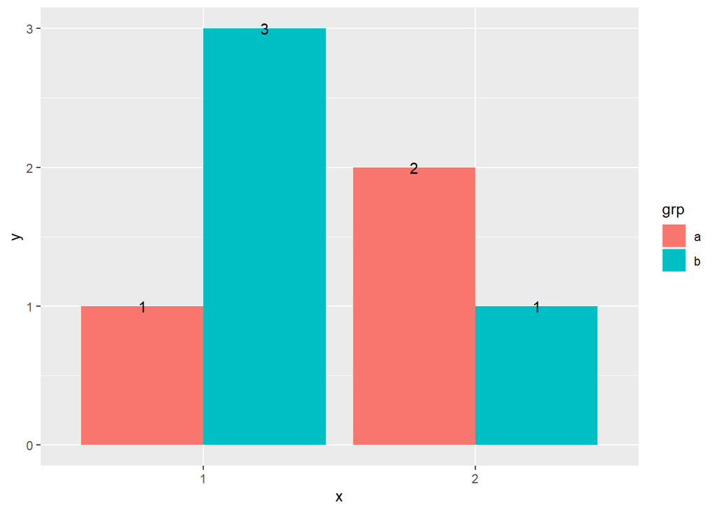

```r
# So tell it:
ggplot(data = df, aes(x, y, group = grp)) +
  geom_col(aes(fill = grp), position = "dodge") +
  geom_text(aes(label = y), position = position_dodge(0.9))
```

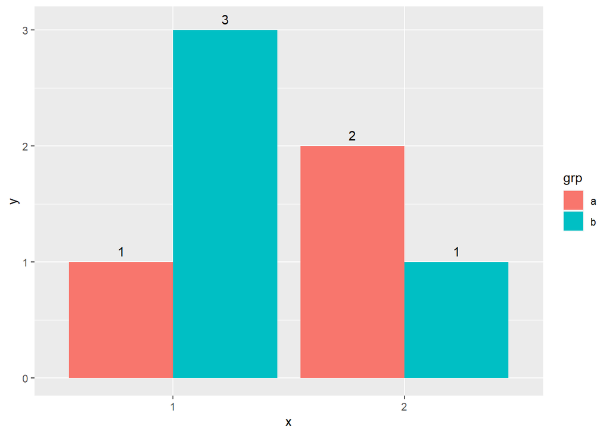

```r
# Use you can't nudge and dodge text, so instead adjust the y position
ggplot(data = df, aes(x, y, group = grp)) +
  geom_col(aes(fill = grp), position = "dodge") +
  geom_text(
    aes(label = y, y = y + 0.05),
    position = position_dodge(0.9),
    vjust = 0
  )
```

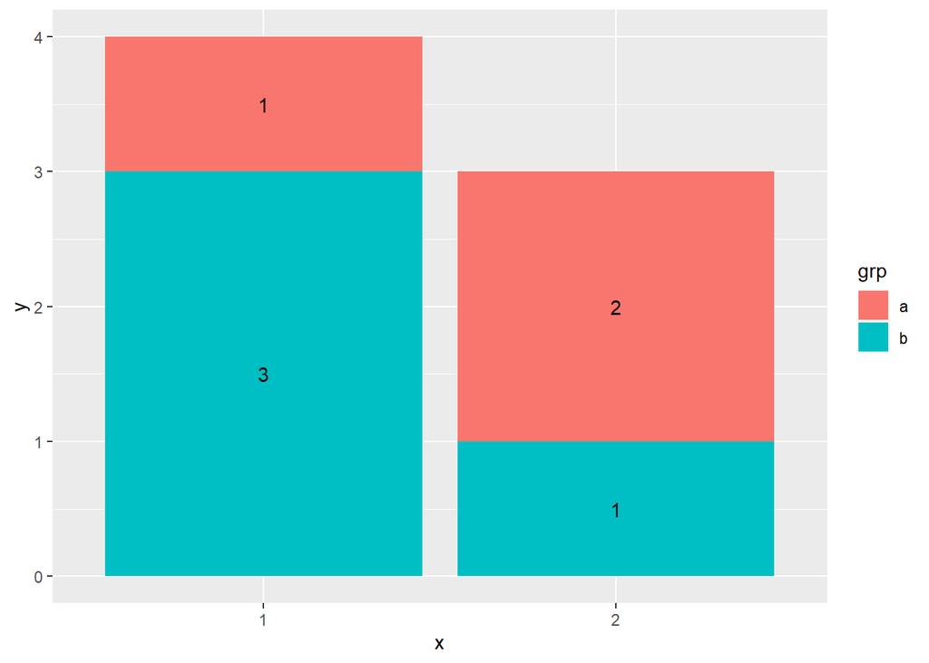

```r
# To place text in the middle of each bar in a stacked barplot, you
# need to set the vjust parameter of position_stack()
ggplot(data = df, aes(x, y, group = grp)) +
 geom_col(aes(fill = grp)) +
 geom_text(aes(label = y), position = position_stack(vjust = 0.5))
```

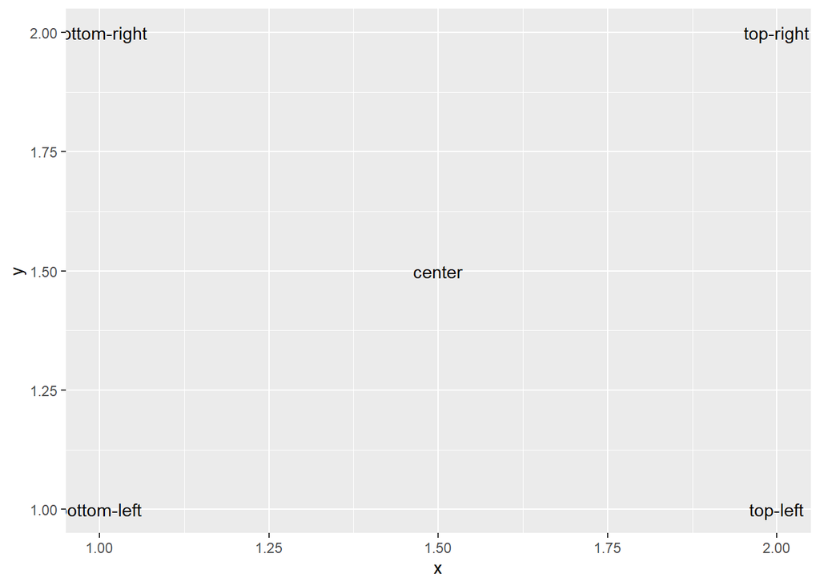

```r
# Justification -------------------------------------------------------------
df <- data.frame(
  x = c(1, 1, 2, 2, 1.5),
  y = c(1, 2, 1, 2, 1.5),
  text = c("bottom-left", "bottom-right", "top-left", "top-right", "center")
)
ggplot(df, aes(x, y)) +
  geom_text(aes(label = text))
```

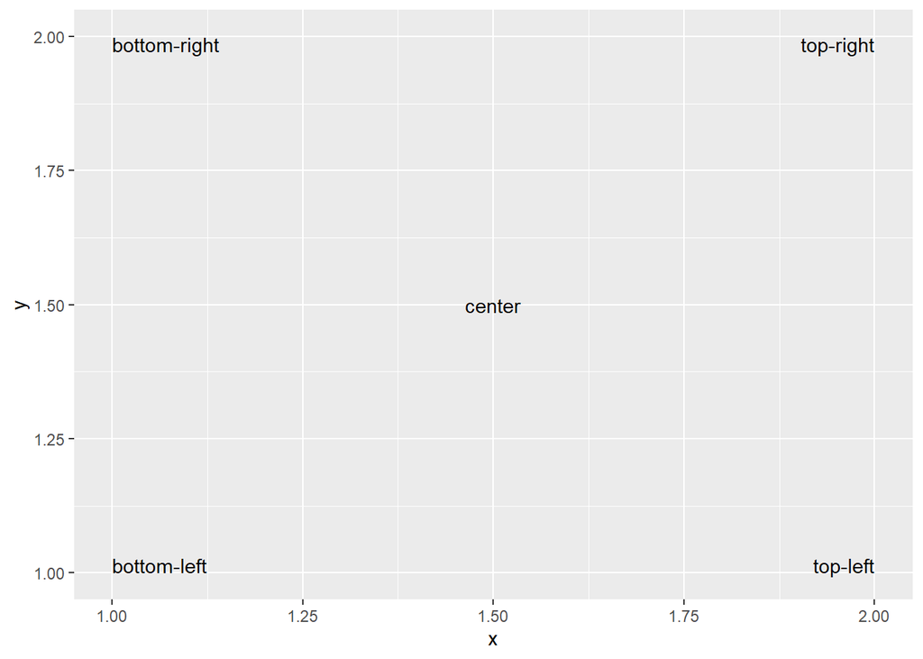

```r
ggplot(df, aes(x, y)) +
  geom_text(aes(label = text), vjust = "inward", hjust = "inward")
```

## Escalas

La tercera forma en que puedes mejorar tu gráfico para comunicar es ajustar las escalas. Las escalas controla el mapeo de los valores de los datos a cosas que puedes percibir.

```r
ggplot(millas, aes(cilindrada, autopista)) +
  geom_point(aes(colour = clase))
```

[output not shown]

```r
ggplot(millas, aes(cilindrada, autopista)) +
  geom_point(aes(colour = clase)) +
  scale_x_continuous() +
  scale_y_continuous() +
  scale_colour_discrete()
```

[output not shown]

Los nombres de las escalas comienzan siempre igual: scale_ seguido del nombre de la estética, luego _ y finalmente el nombre de la escala:  
scale_ x _ continuos  
scale_ y _ continuos  
sacle_ colour _ discrete

Las escalas predeterminadas se nombran según el tipo de variable con la que se alinean: continua, discreta, fecha y hora (datetime) o fecha.

Puede que quieras sobrescribir los valores predeterminados, por dos razones: 1. Modificar los parámetros de la escala predeterminada:  
* intervalos de valores en los ejes  
* etiquetas de cada valor visible  
2. reemplazar la escala por completo:  
* utilizar algoritmo completamente distinto.

### Marca de los ejes y etiquetas

Hay 2 argumentos que los afectan: 1. breaks: controlan la posición de las marcas en los ejes o los valores asociados con las leyendas  
2. labels: controlan la etiqueta de texto asociada con cada marca/leyenda

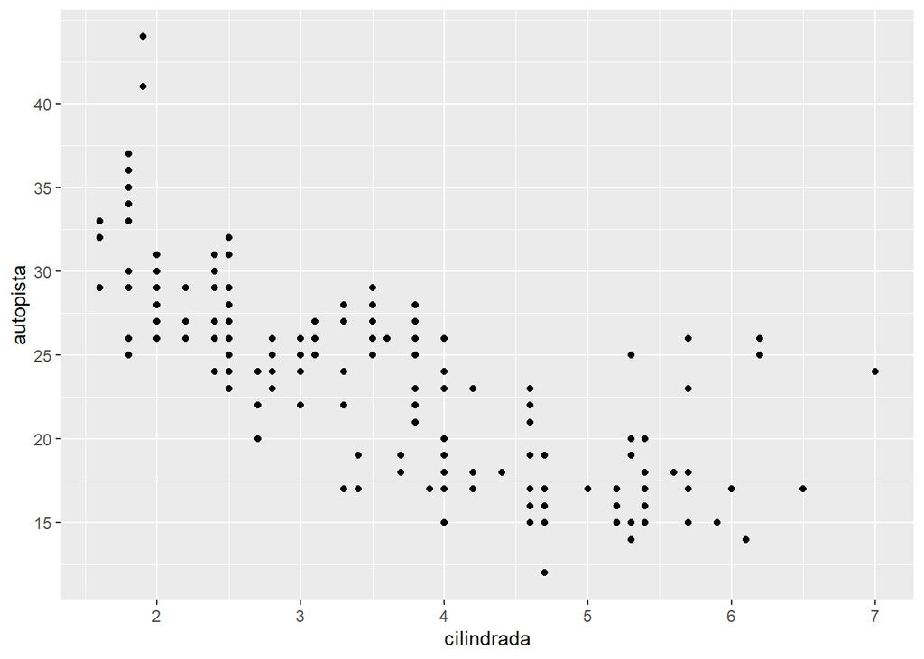

```r
ggplot(millas, aes(cilindrada, autopista)) +
  geom_point() +
  scale_y_continuous(breaks = seq(15, 40, by = 5))
```

Puedes usar labels de la misma manera (un vector de caracteres de la misma longitud que breaks), o puedes establecerlas como NULL del inglés nulo, para suprimir las etiquetas por completo. Esto es útil para mapas, o para publicar gráficos donde no puedes compartir los números absolutos.

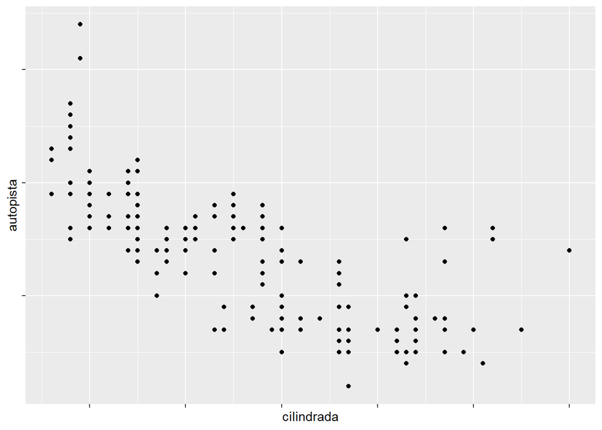

```r
ggplot(millas, aes(cilindrada, autopista)) +
  geom_point() +
  scale_x_continuous(labels = NULL) +
  scale_y_continuous(labels = NULL)
```

En conjunto, los ejes y las leyendas se llaman guías. Los ejes se usan para la estética de x e y; las leyendas se usan para todo lo demás.  
Otro uso de los breaks es cuando tienes relativamente pocos puntos de datos y deseas resaltar exactamente dónde se producen las observaciones.

En el siguiente caso nos interesa remarcar el inicio de las presidencias:

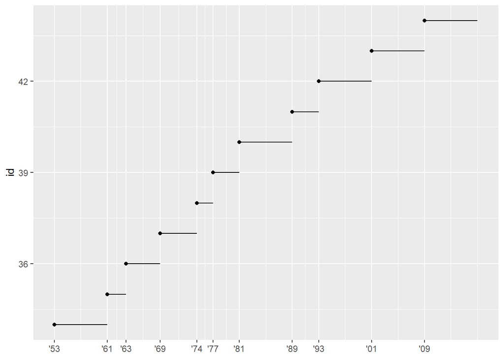

```r
presidencial %>%
  mutate(id = 33 + row_number()) %>%
  ggplot(aes(inicio, id)) +
  geom_point() +
  geom_segment(aes(xend = fin, yend = id)) +
  scale_x_date(NULL, breaks = presidencial$inicio, date_labels = "'%y")
```

Ten en cuenta que la especificación de breaks y labels para escalas en formato de fecha y fecha y hora es ligeramente diferente:

date_labels toma en cuenta la especificación de formato, en la misma forma que parse_datetime().

date_breaks, toma una cadena como “2 días” o “1 mes”.

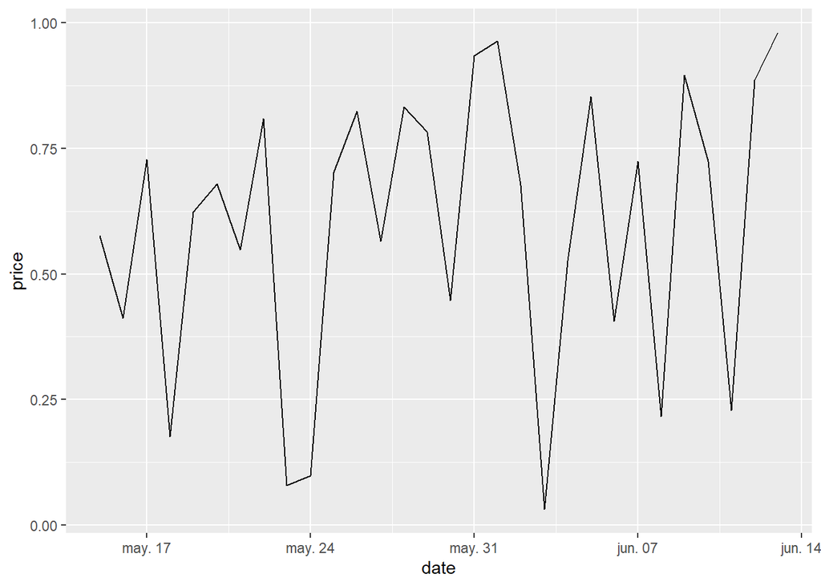

```r
# ver para tener todas las definciones scale_date {ggplot2}
#también se puede establecer el formato de las fechas con date_labels.
# Los códigos estan definidos en strftime().
# Si se especifican tanto labels como date_label, prevalece date_labels.
#date_minor_breaks es un string que define la distancia entre los beraks, por ej. "2 weeks" o "10 years". Idem date_labels... date_minor_breaks prevalece frente a minor_breaks.

last_month <- Sys.Date() - 0:29
df <- data.frame(
  date = last_month,
  price = runif(30)
)
base <- ggplot(df, aes(date, price)) +
  geom_line()

# The date scale will attempt to pick sensible defaults for
# major and minor tick marks. Override with date_breaks, date_labels
# date_minor_breaks arguments.
base + scale_x_date(date_labels = "%b %d")
```

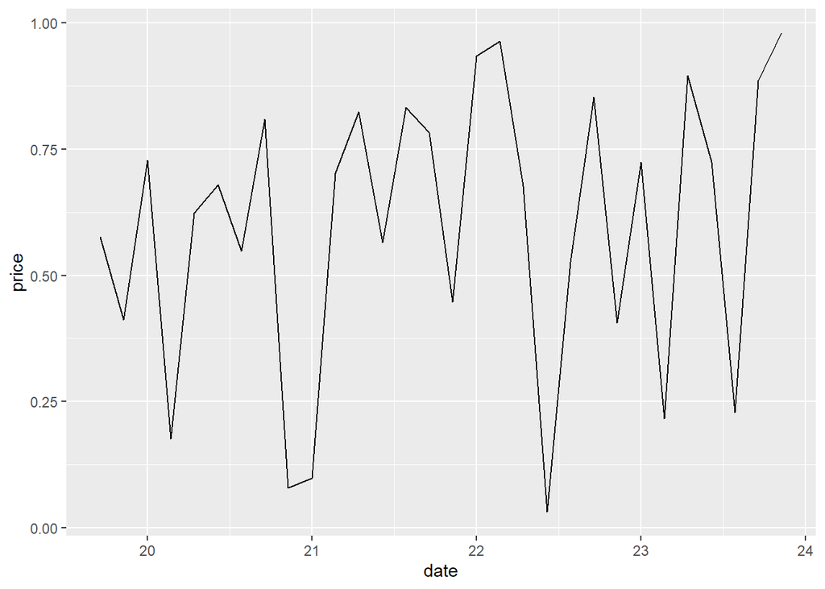

```r
base + scale_x_date(date_breaks = "1 week", date_labels = "%W")
```

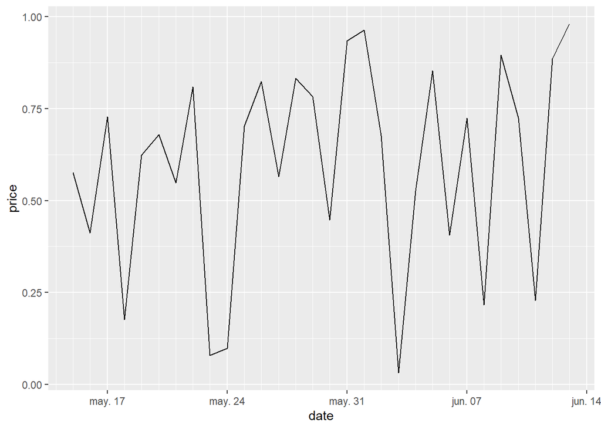

```r
base + scale_x_date(date_minor_breaks = "1 day")
```

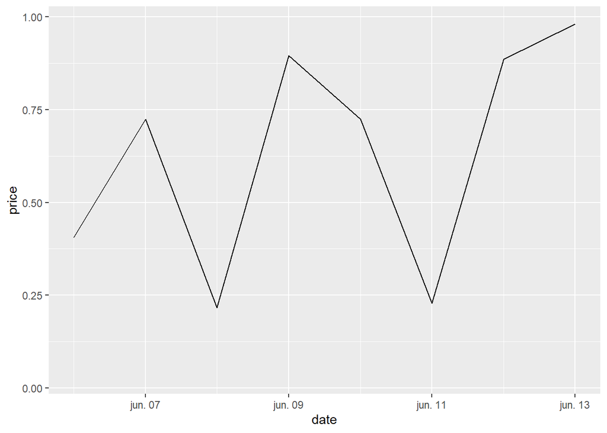

```r
# Set limits
base + scale_x_date(limits = c(Sys.Date() - 7, NA))
```

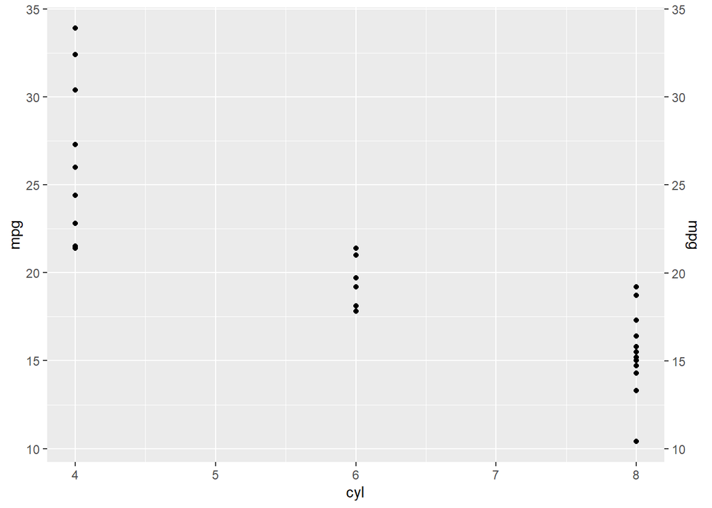

```r
p <- ggplot(mtcars, aes(cyl, mpg)) +
  geom_point()
p + scale_y_continuous(sec.axis = dup_axis()) # Duplicate the primary axis
```

```r
# para fechas
df <- data.frame(
  dx = seq(as.POSIXct("2012-02-29 12:00:00",
                       tz = "UTC",
                       format = "%Y-%m-%d %H:%M:%S"
  ),
  length.out = 10, by = "4 hour"
  ),
  price = seq(20, 200000, length.out = 10)
 )
```

También se pueden definir ejes secundarios. Define otro eje en el lado opuesto

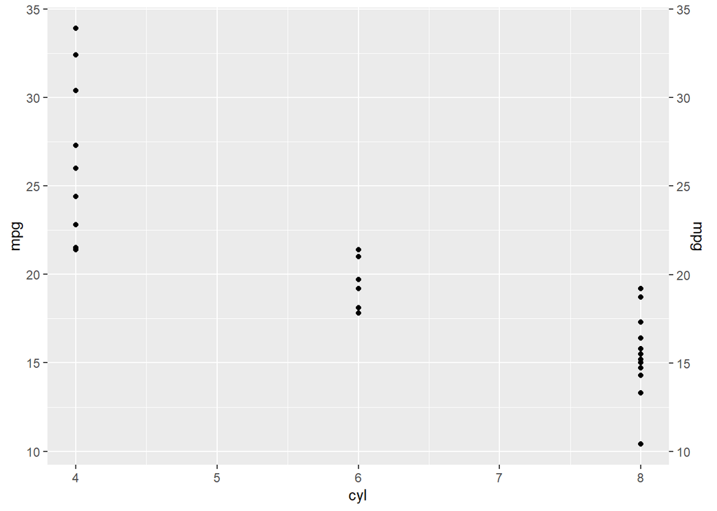

```r
p <- ggplot(mtcars, aes(cyl, mpg)) +
  geom_point()
p + scale_y_continuous(sec.axis = dup_axis()) # Duplicate the primary axis
```

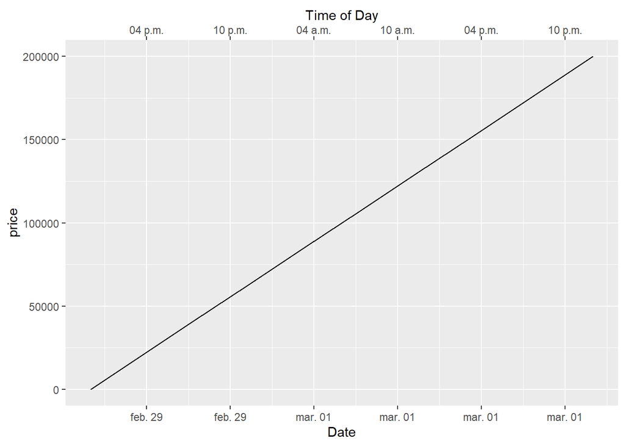

```r
# para fechas
df <- data.frame(
  dx = seq(as.POSIXct("2012-02-29 12:00:00",
                       tz = "UTC",
                       format = "%Y-%m-%d %H:%M:%S"
  ),
  length.out = 10, by = "4 hour"
  ),
  price = seq(20, 200000, length.out = 10)
 )

ggplot(df, aes(x = dx, y = price)) + geom_line() +
  scale_x_datetime("Date", date_labels = "%b %d",
  date_breaks = "6 hour",
  sec.axis = dup_axis(name = "Time of Day",
  labels = scales::time_format("%I %p")))
```

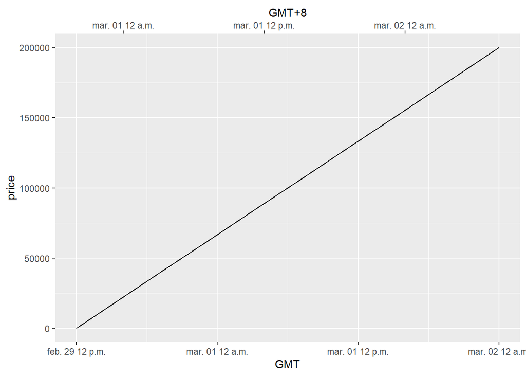

```r
# or to transform axes for different timezones
ggplot(df, aes(x = dx, y = price)) + geom_line() +
  scale_x_datetime("GMT", date_labels = "%b %d %I %p",
  sec.axis = sec_axis(~ . + 8 * 3600, name = "GMT+8",
  labels = scales::time_format("%b %d %I %p")))
```

## Diseño de leyendas:

Con mayor frecuencia utilizarás breaks y labels para ajustar los ejes. Aunque ambos también funcionan con leyendas, hay algunas otras técnicas que se pueden usar.

Para controlar la posición general de la leyenda, debes usar una configuración de theme().

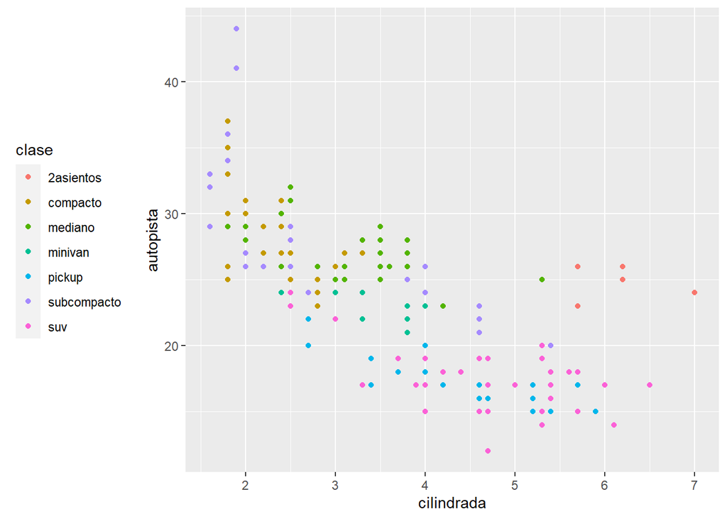

```r
base1 <- ggplot(millas, aes(cilindrada, autopista)) +
  geom_point(aes(colour = clase))

base1 + theme(legend.position = "left")
```

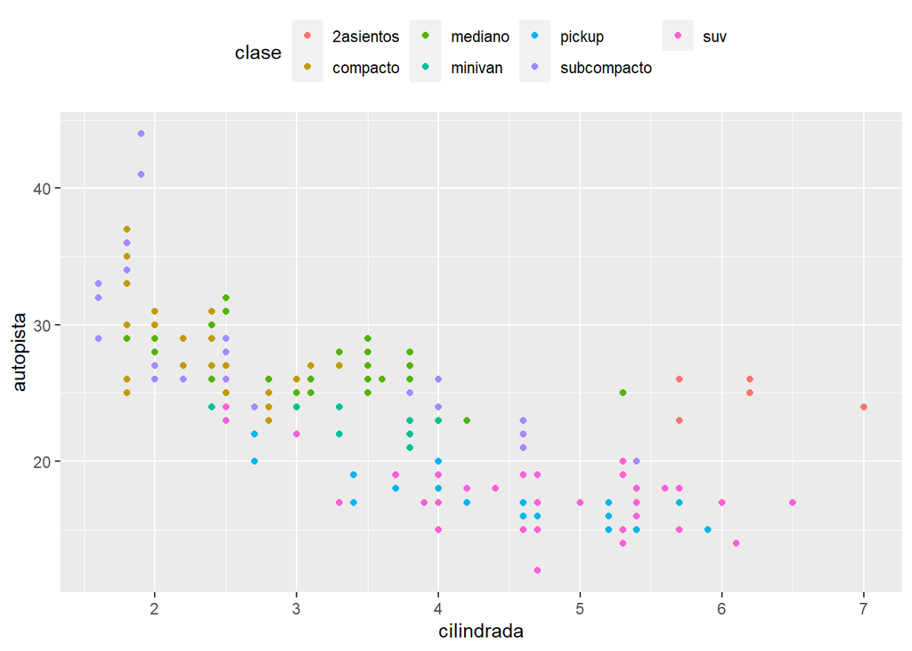

```r
base1 + theme(legend.position = "top")
```

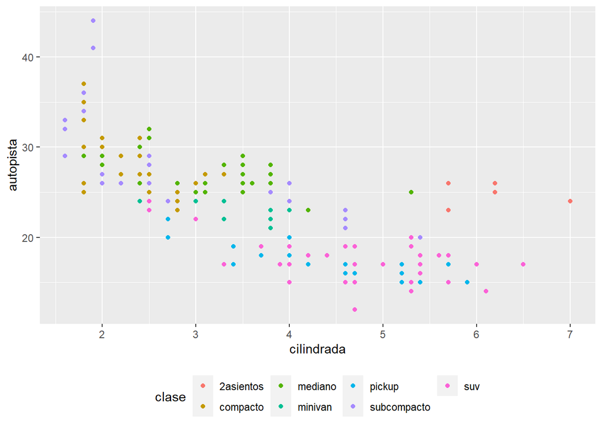

```r
base1 + theme(legend.position = "bottom")
```

```r
base1 + theme(legend.position = "right")
```

[output not shown]

```r
# También puedes usar legend.position = "none" para suprimir por completo la visualización de la leyenda.
```

Para controlar la visualización de leyendas individuales, usa guides() junto con guide_legend() o guide_colourbar()

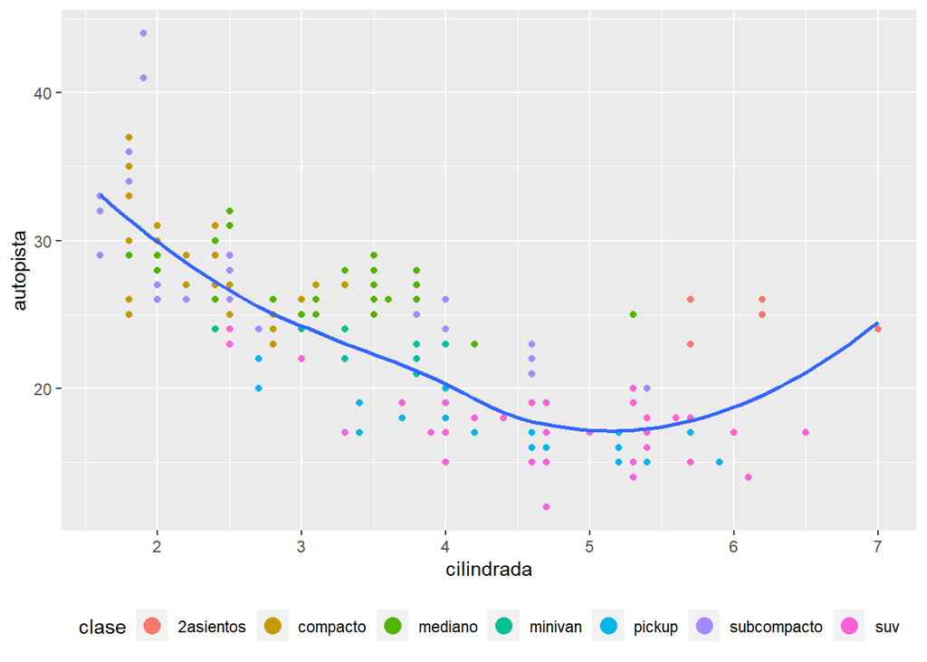

```r
# ejemplo muestra dos configuraciones importantes:
# controlar el número de filas que usa la leyenda con nrow
# redefinir una de las estéticas para agrandar los puntos: Esto es particularmente útil si has usado un valor de alfa bajo para mostrar muchos puntos en un diagrama.

ggplot(millas, aes(cilindrada, autopista)) +
  geom_point(aes(colour = clase)) +
  geom_smooth(se = FALSE) +
  theme(legend.position = "bottom") +
  guides(colour = guide_legend(nrow = 1, override.aes = list(size = 4))) #observar limite nro. de lineas  usadas en legenda (al ser posición bottom)
```

## Reemplazando una escala:

En lugar de simplemente modificar un poco los detalles, puedes reemplazar la escala por completo. Hay dos tipos de escalas que es probable que desees cambiar: escalas de posición continua y escalas de color.

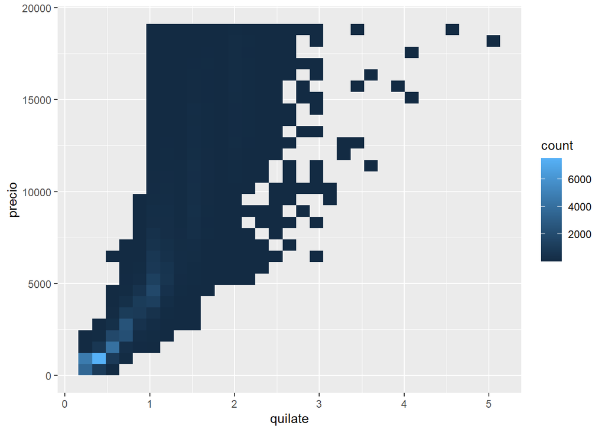

```r
ggplot(diamantes, aes(quilate, precio)) +
  geom_bin2d()
```

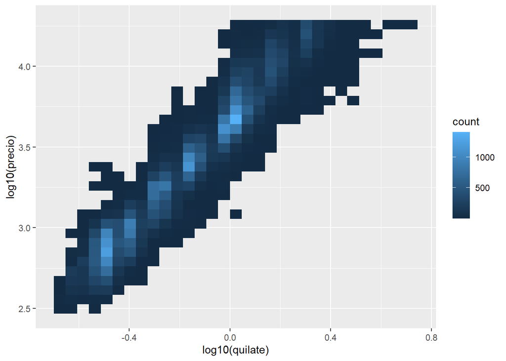

```r
ggplot(diamantes, aes(log10(quilate), log10(precio))) + #notar nombre de los ejes
  geom_bin2d()
```

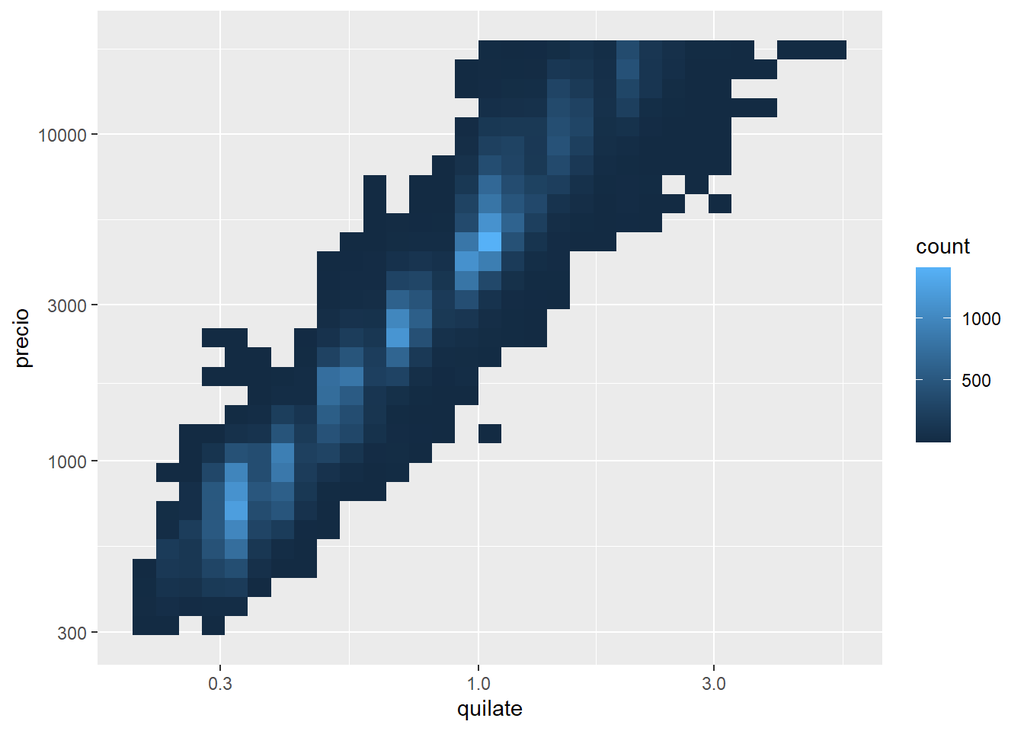

```r
ggplot(diamantes, aes(quilate, precio)) +   #mejora en nombre ejes
  geom_bin2d() +
  scale_x_log10() +
  scale_y_log10()
```

También es común cambiar escala de colores:

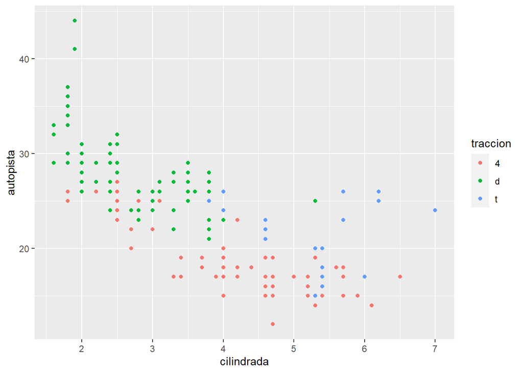

```r
ggplot(millas, aes(cilindrada, autopista)) +
  geom_point(aes(color = traccion))
```

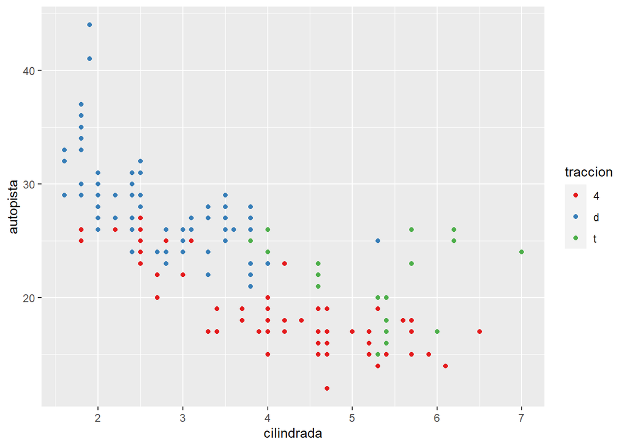

```r
ggplot(millas, aes(cilindrada, autopista)) +
  geom_point(aes(color = traccion)) +
  scale_colour_brewer(palette = "Set1")
```

No olvides las técnicas más simples. **Si solo hay unos pocos colores**, puedes agregar un mapeo de forma redundante. Esto también ayudará a asegurar que tu gráfico sea interpretable en blanco y negro.

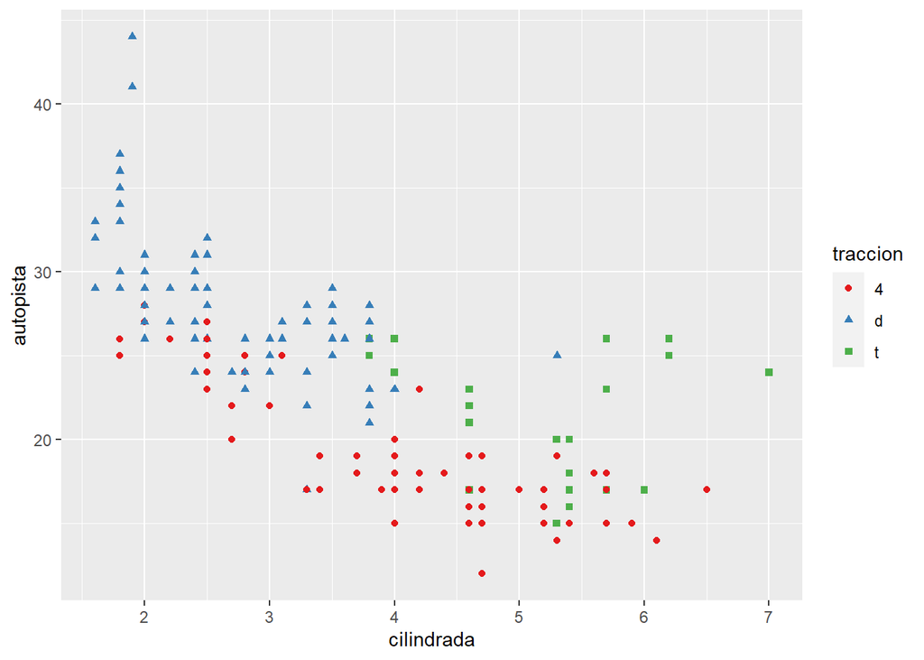

```r
ggplot(millas, aes(cilindrada, autopista)) +
  geom_point(aes(color = traccion, shape = traccion)) +
  scale_colour_brewer(palette = "Set1")
```

**Importante** Las escalas de ColorBrewer están documentadas en línea en http://colorbrewer2.org/ y están disponibles en R en el paquete RColorBrewer de Erich Neuwirth.

En R4DS se listan también. Las paletas secuenciales (arriba) y divergentes (abajo) son particularmente útiles si sus valores categóricos están ordenados o tienen un “centro”. Esto a menudo ocurre si has utilizado **cut()** para convertir una variable continua en una variable categórica.

Cuando tengas un mapeo predefinido entre valores y colores, usa scale_colour_manual().

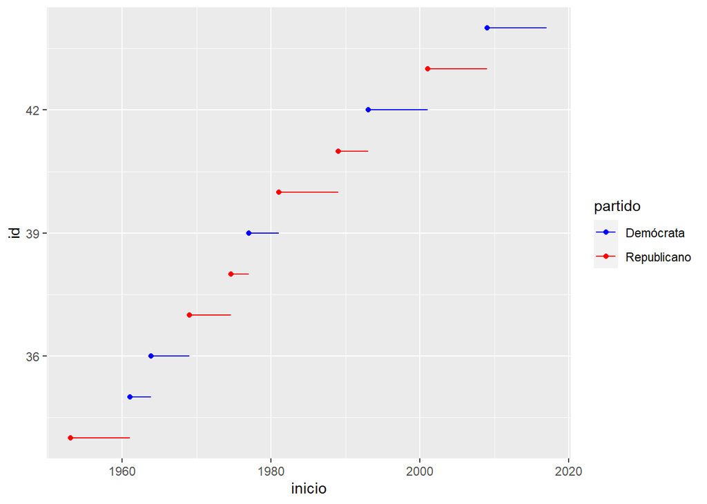

```r
presidencial %>%
  mutate(id = 33 + row_number()) %>%
  ggplot(aes(inicio, id, colour = partido)) +
  geom_point() +
  geom_segment(aes(xend = fin, yend = id)) +
  scale_colour_manual(values = c(Republicano = "red", Demócrata = "blue"))
```

Para generar una escala de color para variables continuas , puedes usar built in scale_colour_gradient() o scale_fill_gradient(). Si tienes una escala divergente, puedes usar scale_colour_gradient2(). Eso tepermite dar, por ejemplo, diferentes colores a valores positivos y negativos. Esto a veces también es útil si quieres distinguir puntos por encima o por debajo de la media.

Otra opción es scale_colour_viridis() proporcionada por el paquete **viridis**: es un análogo continuo de las escalas categóricas de ColorBrewer.

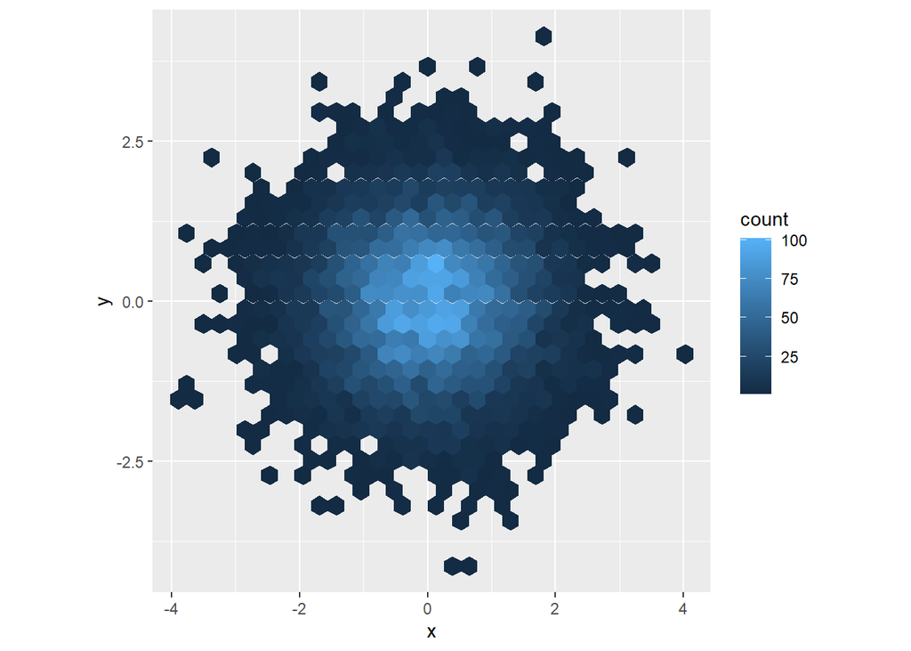

```r
df <- tibble(
  x = rnorm(10000),
  y = rnorm(10000)
)
ggplot(df, aes(x, y)) +
  geom_hex() +
  coord_fixed()
```

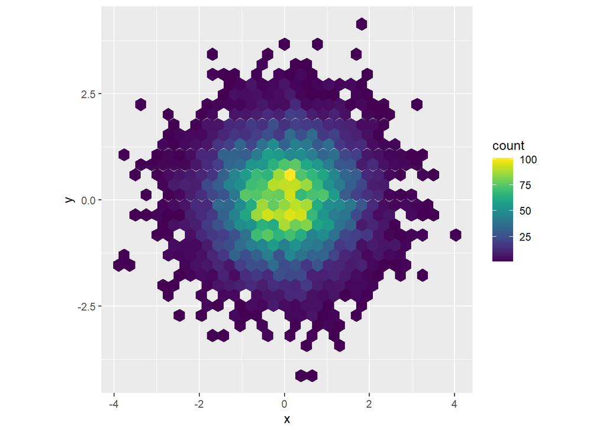

```r
#viridis (no se carga)
ggplot(df, aes(x, y)) +
  geom_hex() +
  viridis::scale_fill_viridis() +
  coord_fixed()
```

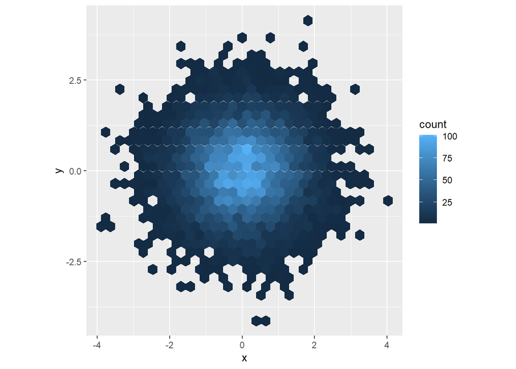

```r
# 1. ¿Por qué el siguiente código no reemplaza la escala predeterminada?
#     scale_fill_gradient en vez de  scale_colour_gradient

ggplot(df, aes(x, y)) +
 geom_hex() +
 scale_colour_gradient(low = "white", high = "red") +
 coord_fixed()
```

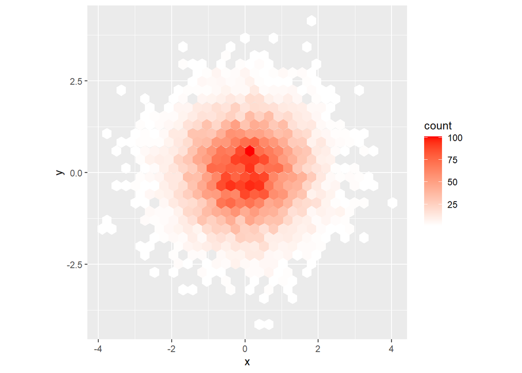

```r
ggplot(df, aes(x, y)) +  # version corregida necesita que sea fill, no colour
  geom_hex() +
  scale_fill_gradient(low = "white", high = "red") +
  coord_fixed()
```

## Haciendo Zoom:

Hay tres formas de controlar los límites de un gráfico:

Modificando los datos que se grafican Estableciendo los límites en cada escala Estableciendo xlim y ylim en coord_cartesian(): **Para ampliar una región del gráfico, generalmente es mejor usar coord_cartesian()**

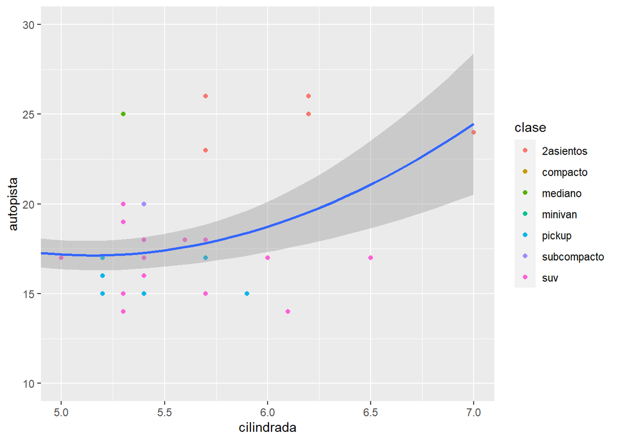

```r
ggplot(millas, mapping = aes(cilindrada, autopista)) +
  geom_point(aes(color = clase)) +
  geom_smooth() +
  coord_cartesian(xlim = c(5, 7), ylim = c(10, 30))
```

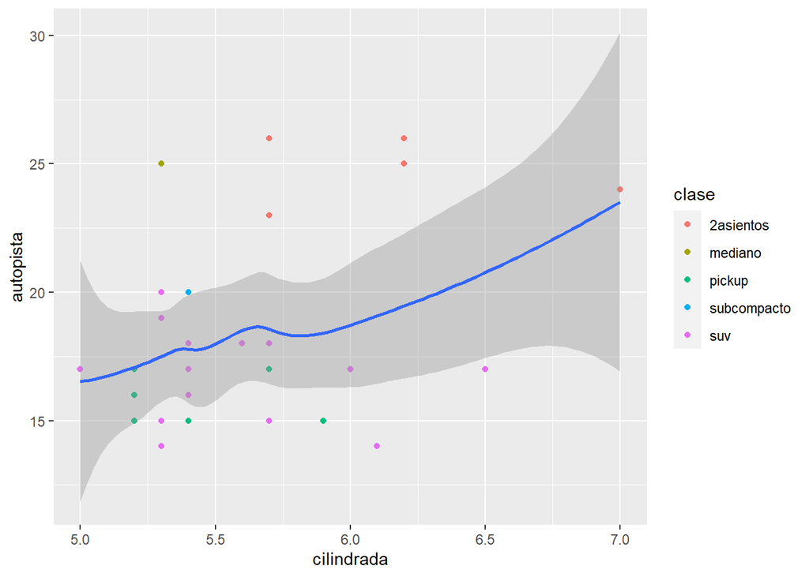

```r
millas %>%
  filter(cilindrada >= 5, cilindrada <= 7, autopista >= 10, autopista <= 30) %>%
  ggplot(aes(cilindrada, autopista)) +
  geom_point(aes(color = clase)) +
  geom_smooth()
```

También puedes establecer limits del inglés límites en escalas individuales. La reducción de los límites del gráfico es equivalente a seleccionar un subconjunto de los datos. En general es más útil si deseas expandir los límites, por ejemplo, cuando quieres hacer coincidir escalas de diferentes gráficos. A modo de ejemplo, si extraemos dos clases de automóviles y los graficamos por separado, son difíciles de comparar ya que las tres escalas (el eje x, el eje y y la estética del color) tienen rangos diferentes.

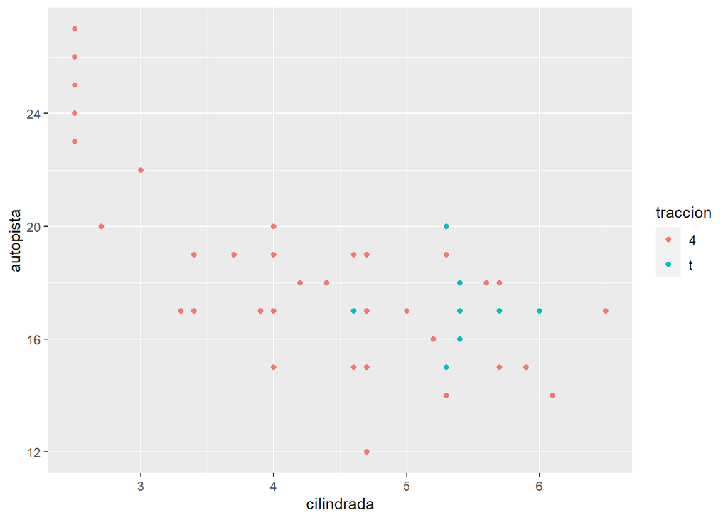

```r
# colores de traccion inconsistentes y

suv <- millas %>% filter(clase == "suv")
compacto <- millas %>% filter(clase == "compacto")

ggplot(suv, aes(cilindrada, autopista, colour = traccion)) +
  geom_point()
```

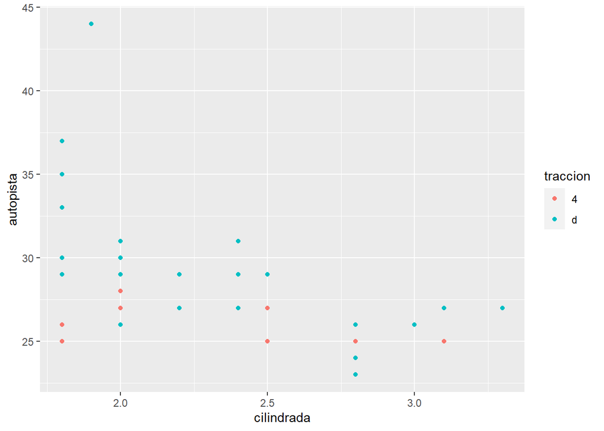

```r
ggplot(compacto, aes(cilindrada, autopista, colour = traccion)) +
  geom_point()
```

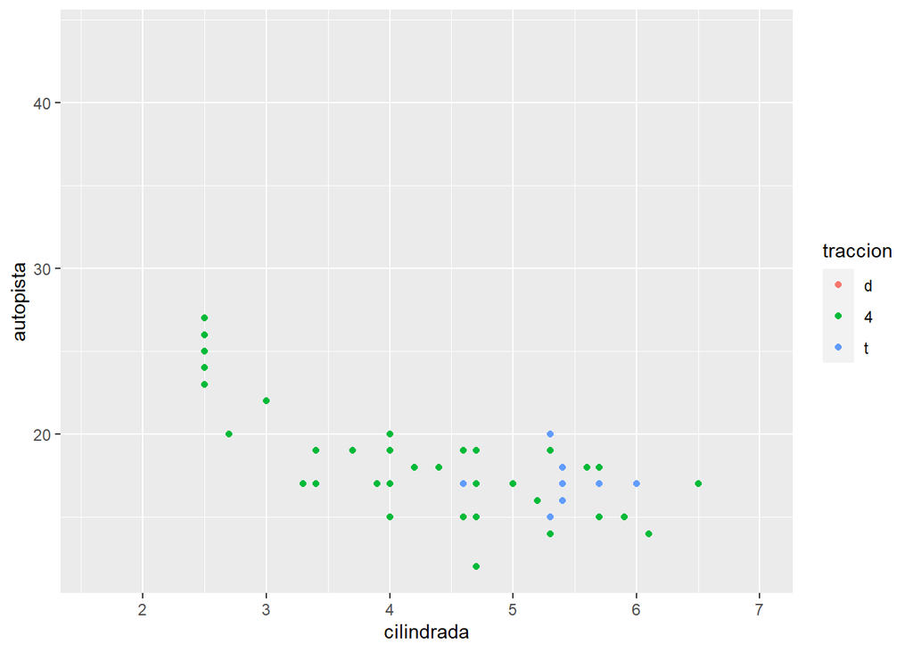

```r
## usando limits y range para definir los limites (range da el valor minimo y máximo)
## notar como x_scale, y_scale, col_scale quedan definidas como environment

x_scale <- scale_x_continuous(limits = range(millas$cilindrada))
y_scale <- scale_y_continuous(limits = range(millas$autopista))
col_scale <- scale_colour_discrete(limits = unique(millas$traccion))

ggplot(suv, aes(cilindrada, autopista, colour = traccion)) +
  geom_point() +
  x_scale +
  y_scale +
  col_scale
```

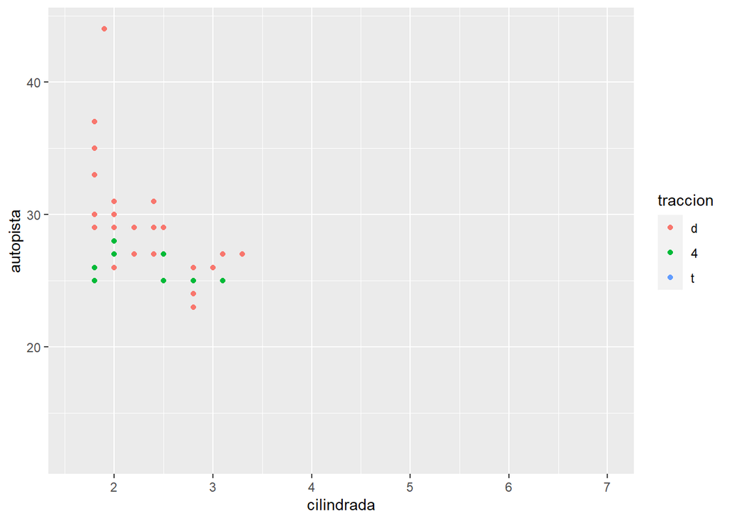

```r
ggplot(compacto, aes(cilindrada, autopista, colour = traccion)) +
  geom_point() +
  x_scale +
  y_scale +
  col_scale
```

```r
# en este caso en particular se podría utilizar facetas para separar en suv y compacto
```

## Temas

ggplot2 incluye ocho temas por defecto:

- theme_bw() fondo blanco con lineas grises
- theme_classic() fondo blanco y ejes pero sin lineas
- theme_dark() fondo oscuro
- theme_gray() default:fondo gris lineas blancas
- theme_light() ejes y grid con lineas suaves
- theme_linedraw() solo lineas negras
- theme_minimal() tema minimo, sin fondo
- theme_void() no tiene nada, solo los geoms

Hay un paquete para poder elegir otros temas: ggthemes (https://github.com/jrnold/ggthemes)

## Guardar graficos:

Si no especificas width y height se usarán las dimensiones del dispositivo empleado para graficar. Para que el código sea reproducible, necesitarás especificarlos.

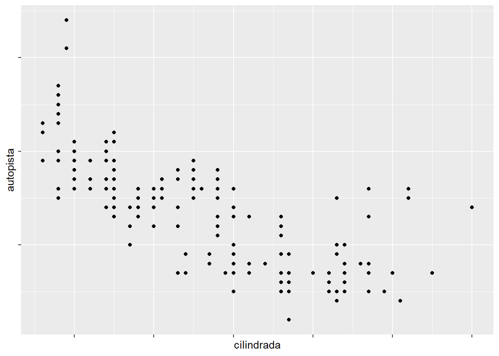

```r
ggplot(millas, aes(cilindrada, autopista)) +
  geom_point() +
  scale_x_continuous(labels = NULL) +
  scale_y_continuous(labels = NULL)
```

```r
ggsave("mi_grafico.pdf")
```

### Redimensionar figura:

Ver en documento de Rmarkdown

### Importantes:

Al mezclar código y texto, como hago en este libro, recomiendo configurar fig.show = “hold” para que los gráficos se muestren después del código.

https://exts.ggplot2.tidyverse.org/gallery/.Este sitio enumera muchos de los paquetes que amplían ggplot2 con nuevos geoms y escalas

https://github.com/hadley/ggplot2-book. para profundizar más sobre ggplot.